# Challenge_6: Basic Principles of Data-Driven Story-telling

weekly_challenges

challenge_6

this is the formal version with updated instructions

Author

Bhavani Priya

Published

November 15, 2023

**Make sure you change the author’s name in the above YAML header.**

## Challenge Overview

In this challenge, we will mainly apply the principles we learned from Jane Miller’s book in practice. You will review multiple examples of data description and presentation intext, table/number, and charts/figures. Please read the instructions for each part and complete your challenges.

**For all the screenshots, images, or tables mentioned in the questions, please see the Challenge_6_Fall23.html file. You don’t need to include any of these items in your rendered challenge file.**

## Part 1. Simple Applications

1. **Recall Jane Miller’s Ws mentioned in Chapter 2. One of the W’s (Who, What, When, and Where, Why) is missing from each of the following table descriptions. Rewrite each sentence to include that information.**

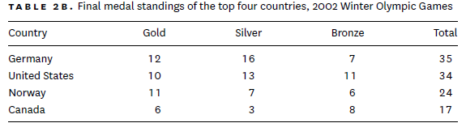

   1. “Germany did the best at the 2002 Winter Olympics, with 35 medals, compared to 34 for the United States, 24 for Norway, and 17 for Canada.”

      In the above sentence ‘Why’ aspect is missing. Why Germany was best In 2002 Winter Olympics, Germany stood first with 35 medals out of which 12 are gold, 16 are silver and 7 are bronze medals, outperforming United Stated which was second in place with a total of 34 medals of which 10 gold, 13 silver and 11 bronze, Norway was in third place with 24 medals and Canada was fourth with a total of 17 medals. Germany has more number of gold - 12 and silver - 16 medals, whereas United states has more bronze medals - 11 among all the four countries.
   2. “Gold, silver, and bronze medals each accounted for about one-third of the medal total.”

   In the 2002 Winter Olympics, Germany, the United States, Norway, and Canada collectively won a total of 110 medals. The distribution included 39 gold, 39 silver, and 32 bronze medals. This balanced distribution across the three medal types, comprising approximately one-third of the total medal count, highlights the competitive performance of these countries in the 2002 Winter Olympics.
   3. “At the 2002 Winter Olympics, the United States won more medals than all other countries, followed by Canada, Germany, and Norway.”

   During the 2002 winter Olympics, the United states has won more Bronze medals than all the other three countries which is 11, Canada won 8 bronze medals making it second, third id Germany with 7 Bronze medals and the last is Norway with 6 Bronze medals.
2. **For each of the following situations, specify whether you would use prose of text, a table of numbers, or a particular type of chart/figure. Explain why you chose this way to present the data.**
   1. Statistics on five types of air pollutants in the 10 largest US cities for a government report

   Table of Numbers Table of Numbers would work effectively for displaying statistics or statistical data of five types of air pollutants in 10 largest US cities. This allows for a clear and concise comparison of values for each type of pollutant across different US cities.
   2. Trends in the value of three stock market indices over one year for a web page

   Line Chart A Line Chart would be a perfect choice for displaying trends over time, it would effectively show the changes in the three stock market values over one year and it would be more accessible for a web page.
   3. Notification to other employees in your corporation of a change in shipping fees

   Prose of Text A written notification in prose is appropriate for conveying straightforward information about a change in shipping fees to employees. This method ensures clarity and direct communication.
   4. Distribution of voter preferences for grade-level composition of a new middle school (grades 5–8, grades 6–8, or grades 6–9) for a presentation at a local school board meeting

   Bar Chart I would prefer using Bar chart for visually representing the distribution of voter preferences for different grade-level compositions(grade 5–8, 6–8 or 6–9) as it provides a clear comparison of preferences and is easy for presentation.
   5. National estimates of the number of uninsured among part-time and full-time workers for an introductory section of an article analyzing effects of employment on insurance coverage in New York City

   Table of Numbers A table of numbers would be suitable for presenting detailed national estimates of uninsured individuals among part-time and full-time workers. This allows for an effective presentation of data, which is appropriate for an introductory section of an analytical article.
3. **Read the sentences below. What additional information would someone need in order to answer the associated question?**
   1. “Brand X costs twice as much as Brand Q. Can I afford Brand X?”

      Individual budget or the maximum amount they can spend.
   2. “My uncle is 6’6” tall? Will he fit in my new car?”

      Dimensions of the car especially headroom, legroom with this information we can determine whether the uncle can fit in the car.
   3. “New Diet Limelite has 25% fewer calories than Diet Fizzjuice. How much faster will I lose weight on Diet Limelite?”

      Total Calorie intake of the person, what other foods is he taking other than New Diet Limelite and information about their overall weight loss plan.
   4. “It has been above 25 degrees every day. We’re really having a warm month, aren’t we?”

      The usual temperature range for that location or region would provide more information to assess whether the current given temperature is really warmer than usual. With this information we can assess that it is a warn month or not.
4. **Indicate whether each of the following sentences correctly reflects table 4B. If not, rewrite the sentence so that it is correct. Check both the correctness and completeness of these sentences.**

   Note: According to [Wikipedia](https://en.wikipedia.org/wiki/Voter_turnout), ” In political science, voter turnout is the participation rate (often defined as those who cast a ballot) of a given election. This is typically the percentage of registered, eligible, or all voting-age people.”

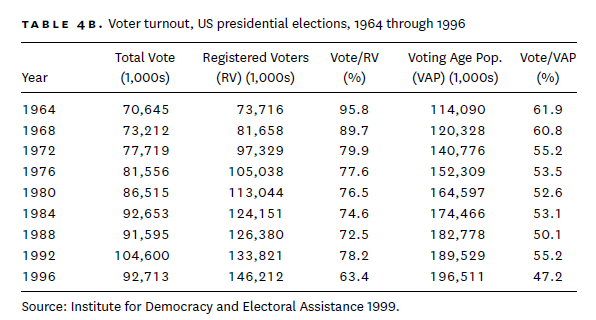

   1. Between 1964 and 1996, there was a steady decline in voter participation.

      Voter turnout was 63.4% in 1996 whereas in 1964 it was 95.8% so we can say that the voter turnout was not better but bad.
   3. The majority of all registered voters participated in the 1964 US presidential election.

      Yes this statement holds true Registered voters were 73,716 and Total votes were 70,645, there is only a minimal difference. The Vote turnout percentage was also high 95.8%. So we can say that majority of regsitered voters participated in 1964 US presidential election.
   4. The best year for voter turnout was 1992, with 104,600 people voting.

   a. “According to the latest study based on the [VDem Dataset](https://v-dem.net/data/the-v-dem-dataset/), the average Rule of Law score is statistically higher in democratic countries than non-democratic countries based on a t-test (p = 0.01).”

   ```
   Rule of Law score
   Statistically Higher
   t-test
   p-value(p=0.01)
   ```

   b. ” According to the logistic regression results in the screenshot below, we can see a positive correlation between household income and the vote choice for G.W. Bush, with a positive coefficient (log-odd = 0.33). ”

   ```
     Logistic Regression
     Positive Correlation
     Positive Coefficient(log-odd = 0.33)
   ```

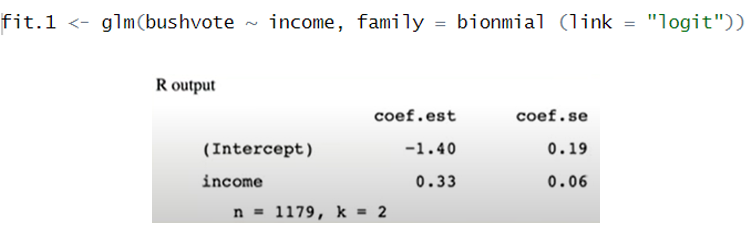

# Part 2. Practical Applications

6. **Suppose you work as a data analyst in the music-producing industry. One day, you get a data report that studies the popularity of different genres of music. The following scatterplot is presented to you. There is no text description for either this table or the data.**

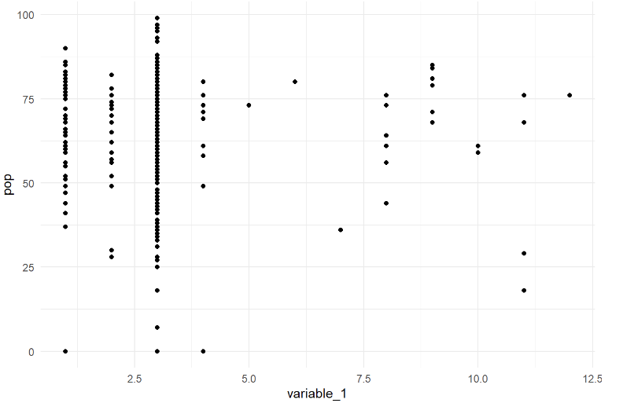

   (1) What information can you describe or summarize based on the current graph?

   Based on the current scatter plot, the y-axis indicates the popularity of the song, whereas I am assuming that the x-axis indicates the sales of the song. High score on the y-axis indicates that the song is more popular. Each point on the scatter plot represents a song. Most songs have an average sale of 3 million assuming that variable_1 is sales, only a few songs have made their way beyong 5 million sales.

   (2) Thinking of the principles we learned in the week of visualization customization and Jane Miller’s principles, What additional information (Please describe at least three things (at least one thing that is NOT about graph customization, such as title, color, label, etc.) that you consider adding this table so that it can convey meaningful information.

   If they have given more information about the x-axis and y-axis, labels and context regarding what each point in the scatter plot means would have been useful. Including some trend line or regression line would have been helpful in understanding the relationship between the variables of x and y-axis.
   - Labels of x and y-axis
   - Context regarding points in scatter plot - if they are songs or artists
   - Trend line to identify the relationship between the variables

   (For your reference, this is the original source of the dataset: https://www.kaggle.com/datasets/leonardopena/top-spotify-songs-from-20102019-by-year)
7. **Two articles on scientific studies talk about the “risks.” Please read the titles and quotes from these two articles and answer the following two questions.**

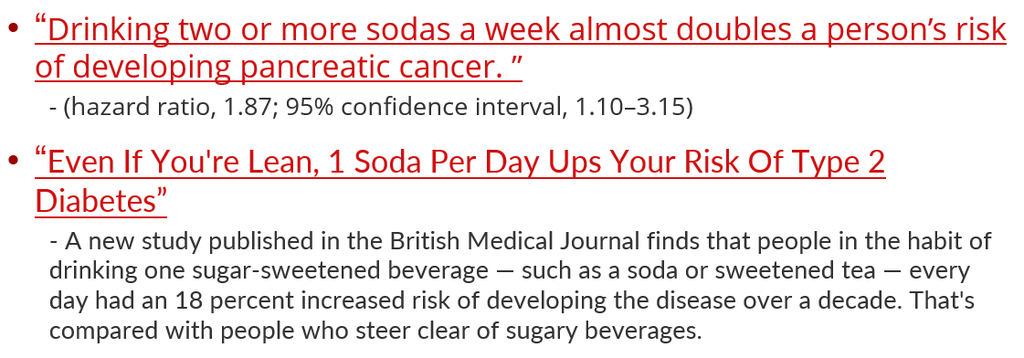

   (1) Given the information provided, in which case is there a greater “risk”: the Pancreatic Cancer case or the Diabetes case?

   We can say that Pancreatic cancer case indicated higher hazard ratio(1.87) with 95% Confidence interval and a doubling of the risk which is more compared to 18% increased risk of developing the disease over a decade in the Diabetes case. Therefore, Pancreatic cancer implies a greater risk.

   (2) Think of Jane Miller’s principles. What additional information would you need to know to compare the “risk” in the two cases?

   To effectively compare the risks in the two cases, it would be helpful to have a common metric for risk. While the Pancreatic Cancer case provides a hazard ratio, the Diabetes case presents an increased risk percentage. It would be beneficial to convert both measures to a consistent metric, such as the hazard ratio, to directly assess and compare the magnitudes of the risks. Additionally, understanding the sample sizes and characteristics of the populations studied in each case would provide some context and would be helpful for the findings.